# Machine Learning Workflow: Classification Trees

Biostat 212A

Author

Dr. Jin Zhou @ UCLA

Published

February 19, 2024

Display system information for reproducibility.

**Python**

```python
import IPython
print(IPython.sys_info())
```

```
{'commit_hash': '37242ba43',
 'commit_source': 'installation',
 'default_encoding': 'utf-8',
 'ipython_path': '/Users/jzhou/anaconda3/lib/python3.11/site-packages/IPython',
 'ipython_version': '8.12.0',
 'os_name': 'posix',
 'platform': 'macOS-14.2.1-arm64-arm-64bit',
 'sys_executable': '/Users/jzhou/anaconda3/bin/python3.11',
 'sys_platform': 'darwin',
 'sys_version': '3.11.3 (main, Apr 19 2023, 18:54:16) [Clang 14.0.6 ]'}
```

## 1 Overview

[figure not shown]

## 2 Heart data

The goal is to predict the binary outcome `AHD` (`Yes` or `No`) of patients.

**R**

```r
library(GGally)
library(gtsummary)
library(ranger)
library(tidyverse)
library(tidymodels)
library(ISLR2)

Heart <- read_csv("../data/Heart.csv")
Heart <- Heart[, -1]
Heart <- na.omit(Heart)
```

```r
Heart %>% tbl_summary()
```

| **Characteristic** | **N = 297**<sup>1</sup> |
| --- | --- |
| Age | 56 (48, 61) |
| Sex | 201 (68%) |
| ChestPain |  |
| asymptomatic | 142 (48%) |
| nonanginal | 83 (28%) |
| nontypical | 49 (16%) |
| typical | 23 (7.7%) |
| RestBP | 130 (120, 140) |
| Chol | 243 (211, 276) |
| Fbs | 43 (14%) |
| RestECG |  |
| 0 | 147 (49%) |
| 1 | 4 (1.3%) |
| 2 | 146 (49%) |
| MaxHR | 153 (133, 166) |
| ExAng | 97 (33%) |
| Oldpeak | 0.80 (0.00, 1.60) |
| Slope |  |
| 1 | 139 (47%) |
| 2 | 137 (46%) |
| 3 | 21 (7.1%) |
| Ca |  |
| 0 | 174 (59%) |
| 1 | 65 (22%) |
| 2 | 38 (13%) |
| 3 | 20 (6.7%) |
| Thal |  |
| fixed | 18 (6.1%) |
| normal | 164 (55%) |
| reversable | 115 (39%) |
| AHD | 137 (46%) |

<sup>1</sup> Median (IQR); n (%)

**Python**

```python
# Load the pandas library
import pandas as pd
# Load numpy for array manipulation
import numpy as np
# Load seaborn plotting library
import seaborn as sns
import matplotlib.pyplot as plt

# Set font sizes in plots
sns.set(font_scale = 1.2)
# Display all columns
pd.set_option('display.max_columns', None)

Heart = pd.read_csv("../data/Heart.csv")
Heart
```

```
     Unnamed: 0  Age  Sex     ChestPain  RestBP  Chol  Fbs  RestECG  MaxHR  \
0             1   63    1       typical     145   233    1        2    150
1             2   67    1  asymptomatic     160   286    0        2    108
2             3   67    1  asymptomatic     120   229    0        2    129
3             4   37    1    nonanginal     130   250    0        0    187
4             5   41    0    nontypical     130   204    0        2    172
..          ...  ...  ...           ...     ...   ...  ...      ...    ...
298         299   45    1       typical     110   264    0        0    132
299         300   68    1  asymptomatic     144   193    1        0    141
300         301   57    1  asymptomatic     130   131    0        0    115
301         302   57    0    nontypical     130   236    0        2    174
302         303   38    1    nonanginal     138   175    0        0    173

     ExAng  Oldpeak  Slope   Ca        Thal  AHD
0        0      2.3      3  0.0       fixed   No
1        1      1.5      2  3.0      normal  Yes
2        1      2.6      2  2.0  reversable  Yes
3        0      3.5      3  0.0      normal   No
4        0      1.4      1  0.0      normal   No
..     ...      ...    ...  ...         ...  ...
298      0      1.2      2  0.0  reversable  Yes
299      0      3.4      2  2.0  reversable  Yes
300      1      1.2      2  1.0  reversable  Yes
301      0      0.0      2  1.0      normal  Yes
302      0      0.0      1  NaN      normal   No

[303 rows x 15 columns]
```

```python
# Numerical summaries
Heart.describe(include = 'all')
```

```
        Unnamed: 0         Age         Sex     ChestPain      RestBP  \
count   303.000000  303.000000  303.000000           303  303.000000
unique         NaN         NaN         NaN             4         NaN
top            NaN         NaN         NaN  asymptomatic         NaN
freq           NaN         NaN         NaN           144         NaN
mean    152.000000   54.438944    0.679868           NaN  131.689769
std      87.612784    9.038662    0.467299           NaN   17.599748
min       1.000000   29.000000    0.000000           NaN   94.000000
25%      76.500000   48.000000    0.000000           NaN  120.000000
50%     152.000000   56.000000    1.000000           NaN  130.000000
75%     227.500000   61.000000    1.000000           NaN  140.000000
max     303.000000   77.000000    1.000000           NaN  200.000000

              Chol         Fbs     RestECG       MaxHR       ExAng  \
count   303.000000  303.000000  303.000000  303.000000  303.000000
unique         NaN         NaN         NaN         NaN         NaN
top            NaN         NaN         NaN         NaN         NaN
freq           NaN         NaN         NaN         NaN         NaN
mean    246.693069    0.148515    0.990099  149.607261    0.326733
std      51.776918    0.356198    0.994971   22.875003    0.469794
min     126.000000    0.000000    0.000000   71.000000    0.000000
25%     211.000000    0.000000    0.000000  133.500000    0.000000
50%     241.000000    0.000000    1.000000  153.000000    0.000000
75%     275.000000    0.000000    2.000000  166.000000    1.000000
max     564.000000    1.000000    2.000000  202.000000    1.000000

           Oldpeak       Slope          Ca    Thal  AHD
count   303.000000  303.000000  299.000000     301  303
unique         NaN         NaN         NaN       3    2
top            NaN         NaN         NaN  normal   No
freq           NaN         NaN         NaN     166  164
mean      1.039604    1.600660    0.672241     NaN  NaN
std       1.161075    0.616226    0.937438     NaN  NaN
min       0.000000    1.000000    0.000000     NaN  NaN
25%       0.000000    1.000000    0.000000     NaN  NaN
50%       0.800000    2.000000    0.000000     NaN  NaN
75%       1.600000    2.000000    1.000000     NaN  NaN
max       6.200000    3.000000    3.000000     NaN  NaN
```

```python
# Graphical summaries
plt.figure()
sns.pairplot(data = Heart);
plt.show()
```

[output not shown]

## 3 Initial split into test and non-test sets

We randomly split the data in half of test data and another half of non-test data. Stratify on `AHD`.

**R**

```r
# For reproducibility
set.seed(212)

data_split <- initial_split(
  Heart,
  prop = 0.5,
  strata = AHD
  )
data_split
```

```
<Training/Testing/Total>
<148/149/297>
```

```r
Heart_other <- training(data_split)
dim(Heart_other)
```

```
[1] 148  14
```

```r
Heart_test <- testing(data_split)
dim(Heart_test)
```

```
[1] 149  14
```

**Python**

```python
from sklearn.model_selection import train_test_split

Heart_other, Heart_test = train_test_split(
  Heart,
  train_size = 0.75,
  random_state = 425, # seed
  stratify = Heart.AHD
  )
Heart_test.shape
```

```
(76, 15)
```

```python
Heart_other.shape
```

```
(227, 15)
```

Separate $X$ and $y$. We will use 13 features.

```python
num_features = ['Age', 'Sex', 'RestBP', 'Chol', 'Fbs', 'RestECG', 'MaxHR', 'ExAng', 'Oldpeak', 'Slope', 'Ca']
cat_features = ['ChestPain', 'Thal']
features = np.concatenate([num_features, cat_features])
# Non-test X and y
X_other = Heart_other[features]
y_other = Heart_other.AHD
# Test X and y
X_test = Heart_test[features]
y_test = Heart_test.AHD
```

## 4 Preprocessing (Python) or recipe (R)

**R**

```r
tree_recipe <-
  recipe(
    AHD ~ .,
    data = Heart_other
  ) %>%
  step_naomit(all_predictors()) %>%
  # # create traditional dummy variables (not necessary for random forest in R)
  step_dummy(all_nominal_predictors()) %>%
  # zero-variance filter
  step_zv(all_numeric_predictors()) %>%
  # # center and scale numeric data (not necessary for random forest)
  step_normalize(all_numeric_predictors()) %>%
  # estimate the means and standard deviations
  prep(training = Heart_other, retain = TRUE)
tree_recipe
```

**Python**

There are missing values in `Ca` (quantitative) and `Thal` (qualitative) variables. We are going to use simple `mean` imputation for `Ca` and `most_frequent` imputation for `Thal`. This is suboptimal. Better strategy is to use multiple imputation.

```python
# How many NaNs
Heart.isna().sum()
```

```
Unnamed: 0    0
Age           0
Sex           0
ChestPain     0
RestBP        0
Chol          0
Fbs           0
RestECG       0
MaxHR         0
ExAng         0
Oldpeak       0
Slope         0
Ca            4
Thal          2
AHD           0
dtype: int64
```

In principle, decision trees should be able to handle categorical predictors. However scikit-learn and xgboost implementations don’t allow categorical predictors and require one-hot encoding.

```python
from sklearn.preprocessing import OneHotEncoder
from sklearn.impute import SimpleImputer
from sklearn.compose import ColumnTransformer
from sklearn.pipeline import Pipeline

# Transformer for categorical variables
categorical_tf = Pipeline(steps = [
  ("cat_impute", SimpleImputer(strategy = 'most_frequent')),
  ("encoder", OneHotEncoder())
])

# Transformer for continuous variables
numeric_tf = Pipeline(steps = [
  ("num_impute", SimpleImputer(strategy = 'mean')),
])

# Column transformer
col_tf = ColumnTransformer(transformers = [
  ('num', numeric_tf, num_features),
  ('cat', categorical_tf, cat_features)
])
```

## 5 Model

**R**

```r
classtree_mod <- decision_tree(
  cost_complexity = tune(),
  tree_depth = tune(),
  min_n = 5,
  mode = "classification",
  engine = "rpart"
  )
```

**Python**

```python
from sklearn.tree import DecisionTreeClassifier, plot_tree

classtree_mod = DecisionTreeClassifier(
  criterion = 'gini',
  random_state = 425
  )
```

## 6 Pipeline (Python) or workflow (R)

Here we bundle the preprocessing step (Python) or recipe (R) and model.

**R**

```r
tree_wf <- workflow() %>%
  add_recipe(tree_recipe) %>%
  add_model(classtree_mod)
tree_wf
```

```
══ Workflow ════════════════════════════════════════════════════════════════════
Preprocessor: Recipe
Model: decision_tree()

── Preprocessor ────────────────────────────────────────────────────────────────
4 Recipe Steps

• step_naomit()
• step_dummy()
• step_zv()
• step_normalize()

── Model ───────────────────────────────────────────────────────────────────────
Decision Tree Model Specification (classification)

Main Arguments:
  cost_complexity = tune()
  tree_depth = tune()
  min_n = 5

Computational engine: rpart
```

**Python**

```python
from sklearn.pipeline import Pipeline

pipe = Pipeline(steps = [
  ("col_tf", col_tf),
  ("model", classtree_mod)
  ])
pipe
```

```
Pipeline(steps=[('col_tf',
                 ColumnTransformer(transformers=[('num',
                                                  Pipeline(steps=[('num_impute',
                                                                   SimpleImputer())]),
                                                  ['Age', 'Sex', 'RestBP',
                                                   'Chol', 'Fbs', 'RestECG',
                                                   'MaxHR', 'ExAng', 'Oldpeak',
                                                   'Slope', 'Ca']),
                                                 ('cat',
                                                  Pipeline(steps=[('cat_impute',
                                                                   SimpleImputer(strategy='most_frequent')),
                                                                  ('encoder',
                                                                   OneHotEncoder())]),
                                                  ['ChestPain', 'Thal'])])),
                ('model', DecisionTreeClassifier(random_state=425))])
```

## 7 Tuning grid

`ccp_alpha` is the Minimal Cost-Complexity Pruning parameter. Greater values of `ccp_alpha` increase the number of nodes pruned.

**R**

```r
tree_grid <- grid_regular(cost_complexity(),
                          tree_depth(),
                          levels = c(100,5))
```

**Python**

```python
# Tune hyper-parameter(s)
ccp_alpha_grid = np.linspace(start = 0.0, stop = 0.05, num = 100)
tuned_parameters = {
  "model__ccp_alpha": ccp_alpha_grid
  }
tuned_parameters
```

```
{'model__ccp_alpha': array([0.        , 0.00050505, 0.0010101 , 0.00151515, 0.0020202 ,
       0.00252525, 0.0030303 , 0.00353535, 0.0040404 , 0.00454545,
       0.00505051, 0.00555556, 0.00606061, 0.00656566, 0.00707071,
       0.00757576, 0.00808081, 0.00858586, 0.00909091, 0.00959596,
       0.01010101, 0.01060606, 0.01111111, 0.01161616, 0.01212121,
       0.01262626, 0.01313131, 0.01363636, 0.01414141, 0.01464646,
       0.01515152, 0.01565657, 0.01616162, 0.01666667, 0.01717172,
       0.01767677, 0.01818182, 0.01868687, 0.01919192, 0.01969697,
       0.02020202, 0.02070707, 0.02121212, 0.02171717, 0.02222222,
       0.02272727, 0.02323232, 0.02373737, 0.02424242, 0.02474747,
       0.02525253, 0.02575758, 0.02626263, 0.02676768, 0.02727273,
       0.02777778, 0.02828283, 0.02878788, 0.02929293, 0.02979798,
       0.03030303, 0.03080808, 0.03131313, 0.03181818, 0.03232323,
       0.03282828, 0.03333333, 0.03383838, 0.03434343, 0.03484848,
       0.03535354, 0.03585859, 0.03636364, 0.03686869, 0.03737374,
       0.03787879, 0.03838384, 0.03888889, 0.03939394, 0.03989899,
       0.04040404, 0.04090909, 0.04141414, 0.04191919, 0.04242424,
       0.04292929, 0.04343434, 0.04393939, 0.04444444, 0.04494949,
       0.04545455, 0.0459596 , 0.04646465, 0.0469697 , 0.04747475,
       0.0479798 , 0.04848485, 0.0489899 , 0.04949495, 0.05      ])}
```

## 8 Cross-validation (CV)

**R**

Set cross-validation partitions.

```r
set.seed(212)

folds <- vfold_cv(Heart_other, v = 5)
folds
```

```
#  5-fold cross-validation
# A tibble: 5 × 2
  splits           id
  <list>           <chr>
1 <split [118/30]> Fold1
2 <split [118/30]> Fold2
3 <split [118/30]> Fold3
4 <split [119/29]> Fold4
5 <split [119/29]> Fold5
```

Fit cross-validation.

```r
tree_fit <- tree_wf %>%
  tune_grid(
    resamples = folds,
    grid = tree_grid,
    metrics = metric_set(accuracy, roc_auc)
    )
tree_fit
```

```
# Tuning results
# 5-fold cross-validation
# A tibble: 5 × 4
  splits           id    .metrics             .notes
  <list>           <chr> <list>               <list>
1 <split [118/30]> Fold1 <tibble [1,000 × 6]> <tibble [0 × 3]>
2 <split [118/30]> Fold2 <tibble [1,000 × 6]> <tibble [0 × 3]>
3 <split [118/30]> Fold3 <tibble [1,000 × 6]> <tibble [0 × 3]>
4 <split [119/29]> Fold4 <tibble [1,000 × 6]> <tibble [0 × 3]>
5 <split [119/29]> Fold5 <tibble [1,000 × 6]> <tibble [0 × 3]>
```

Visualize CV results:

```
# A tibble: 1,000 × 8
   cost_complexity tree_depth .metric  .estimator  mean     n std_err
             <dbl>      <int> <chr>    <chr>      <dbl> <int>   <dbl>
 1        1   e-10          1 accuracy binary     0.696     5  0.0108
 2        1   e-10          1 roc_auc  binary     0.689     5  0.0143
 3        1.23e-10          1 accuracy binary     0.696     5  0.0108
 4        1.23e-10          1 roc_auc  binary     0.689     5  0.0143
 5        1.52e-10          1 accuracy binary     0.696     5  0.0108
 6        1.52e-10          1 roc_auc  binary     0.689     5  0.0143
 7        1.87e-10          1 accuracy binary     0.696     5  0.0108
 8        1.87e-10          1 roc_auc  binary     0.689     5  0.0143
 9        2.31e-10          1 accuracy binary     0.696     5  0.0108
10        2.31e-10          1 roc_auc  binary     0.689     5  0.0143
   .config
   <chr>
 1 Preprocessor1_Model001
 2 Preprocessor1_Model001
 3 Preprocessor1_Model002
 4 Preprocessor1_Model002
 5 Preprocessor1_Model003
 6 Preprocessor1_Model003
 7 Preprocessor1_Model004
 8 Preprocessor1_Model004
 9 Preprocessor1_Model005
10 Preprocessor1_Model005
# ℹ 990 more rows
```

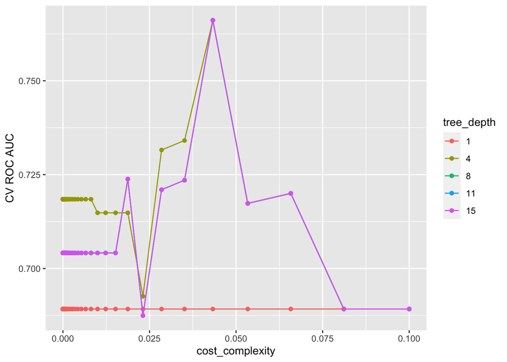

```r
tree_fit %>%
  collect_metrics() %>%
  print(width = Inf) %>%
  filter(.metric == "roc_auc") %>%
  mutate(tree_depth = as.factor(tree_depth)) %>%
  ggplot(mapping = aes(x = cost_complexity, y = mean, color = tree_depth)) +
  geom_point() +
  geom_line() +
  labs(x = "cost_complexity", y = "CV ROC AUC", color = "tree_depth")
```

**Python**

Set up CV partitions and CV criterion.

```python
from sklearn.model_selection import GridSearchCV

# Set up CV
n_folds = 5
search = GridSearchCV(
  pipe,
  tuned_parameters,
  cv = n_folds,
  scoring = "roc_auc",
  # Refit the best model on the whole data set
  refit = True
  )
```

Fit CV. This is typically the most time-consuming step.

```python
# Fit CV
search.fit(X_other, y_other)
```

```
GridSearchCV(cv=5,
             estimator=Pipeline(steps=[('col_tf',
                                        ColumnTransformer(transformers=[('num',
                                                                         Pipeline(steps=[('num_impute',
                                                                                          SimpleImputer())]),
                                                                         ['Age',
                                                                          'Sex',
                                                                          'RestBP',
                                                                          'Chol',
                                                                          'Fbs',
                                                                          'RestECG',
                                                                          'MaxHR',
                                                                          'ExAng',
                                                                          'Oldpeak',
                                                                          'Slope',
                                                                          'Ca']),
                                                                        ('cat',
                                                                         Pipeline(steps=[('cat_impute',
                                                                                          SimpleImputer(strategy='most_frequent')),
                                                                                         ('encoder',
                                                                                          OneHotEncoder())]),
                                                                         ['ChestPain',
                                                                          '...
       0.03282828, 0.03333333, 0.03383838, 0.03434343, 0.03484848,
       0.03535354, 0.03585859, 0.03636364, 0.03686869, 0.03737374,
       0.03787879, 0.03838384, 0.03888889, 0.03939394, 0.03989899,
       0.04040404, 0.04090909, 0.04141414, 0.04191919, 0.04242424,
       0.04292929, 0.04343434, 0.04393939, 0.04444444, 0.04494949,
       0.04545455, 0.0459596 , 0.04646465, 0.0469697 , 0.04747475,
       0.0479798 , 0.04848485, 0.0489899 , 0.04949495, 0.05      ])},
             scoring='roc_auc')
```

Visualize CV results.

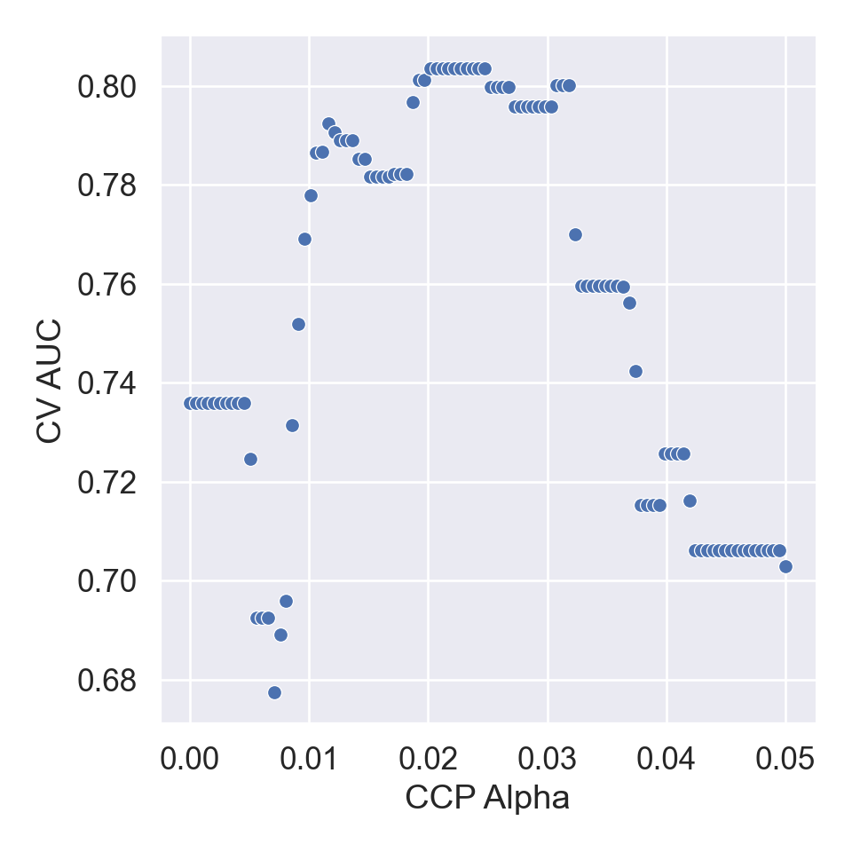

```python
cv_res = pd.DataFrame({
  "ccp_alpha": np.array(search.cv_results_["param_model__ccp_alpha"]),
  "auc": search.cv_results_["mean_test_score"]
  })

plt.figure()
sns.relplot(
  # kind = "line",
  data = cv_res,
  x = "ccp_alpha",
  y = "auc"
  ).set(
    xlabel = "CCP Alpha",
    ylabel = "CV AUC"
);
plt.show()
```

Best CV AUC:

```python
search.best_score_
```

```
0.803652380952381
```

The training accuracy is

```python
from sklearn.metrics import accuracy_score, roc_auc_score

accuracy_score(
  y_other,
  search.best_estimator_.predict(X_other)
  )
```

```
0.8149779735682819
```

## 9 Finalize our model

Now we are done tuning. Finally, let’s fit this final model to the whole training data and use our test data to estimate the model performance we expect to see with new data.

**R**

```r
tree_fit %>%
  show_best("roc_auc")
```

```
# A tibble: 5 × 8
  cost_complexity tree_depth .metric .estimator  mean     n std_err .config
            <dbl>      <int> <chr>   <chr>      <dbl> <int>   <dbl> <chr>
1          0.0433          4 roc_auc binary     0.766     5  0.0291 Preprocesso…
2          0.0433          8 roc_auc binary     0.766     5  0.0291 Preprocesso…
3          0.0433         11 roc_auc binary     0.766     5  0.0291 Preprocesso…
4          0.0433         15 roc_auc binary     0.766     5  0.0291 Preprocesso…
5          0.0351          4 roc_auc binary     0.734     5  0.0258 Preprocesso…
```

Let’s select the best model.

```r
best_tree <- tree_fit %>%
  select_best("roc_auc")
best_tree
```

```
# A tibble: 1 × 3
  cost_complexity tree_depth .config
            <dbl>      <int> <chr>
1          0.0433          4 Preprocessor1_Model196
```

```r
# Final workflow
final_wf <- tree_wf %>%
  finalize_workflow(best_tree)
final_wf
```

```
══ Workflow ════════════════════════════════════════════════════════════════════
Preprocessor: Recipe
Model: decision_tree()

── Preprocessor ────────────────────────────────────────────────────────────────
4 Recipe Steps

• step_naomit()
• step_dummy()
• step_zv()
• step_normalize()

── Model ───────────────────────────────────────────────────────────────────────
Decision Tree Model Specification (classification)

Main Arguments:
  cost_complexity = 0.0432876128108306
  tree_depth = 4
  min_n = 5

Computational engine: rpart
```

```r
# Fit the whole training set, then predict the test cases
final_fit <-
  final_wf %>%
  last_fit(data_split)
final_fit
```

```
# Resampling results
# Manual resampling
# A tibble: 1 × 6
  splits            id               .metrics .notes   .predictions .workflow
  <list>            <chr>            <list>   <list>   <list>       <list>
1 <split [148/149]> train/test split <tibble> <tibble> <tibble>     <workflow>
```

```r
# Test metrics
final_fit %>%
  collect_metrics()
```

```
# A tibble: 2 × 4
  .metric  .estimator .estimate .config
  <chr>    <chr>          <dbl> <chr>
1 accuracy binary         0.779 Preprocessor1_Model1
2 roc_auc  binary         0.807 Preprocessor1_Model1
```

**Python**

Since we called `GridSearchCV` with `refit = True`, the best model fit on the whole non-test data is readily available.

```python
search.best_estimator_
```

```
Pipeline(steps=[('col_tf',
                 ColumnTransformer(transformers=[('num',
                                                  Pipeline(steps=[('num_impute',
                                                                   SimpleImputer())]),
                                                  ['Age', 'Sex', 'RestBP',
                                                   'Chol', 'Fbs', 'RestECG',
                                                   'MaxHR', 'ExAng', 'Oldpeak',
                                                   'Slope', 'Ca']),
                                                 ('cat',
                                                  Pipeline(steps=[('cat_impute',
                                                                   SimpleImputer(strategy='most_frequent')),
                                                                  ('encoder',
                                                                   OneHotEncoder())]),
                                                  ['ChestPain', 'Thal'])])),
                ('model',
                 DecisionTreeClassifier(ccp_alpha=0.0202020202020202,
                                        random_state=425))])
```

Visualize the best classification tree.

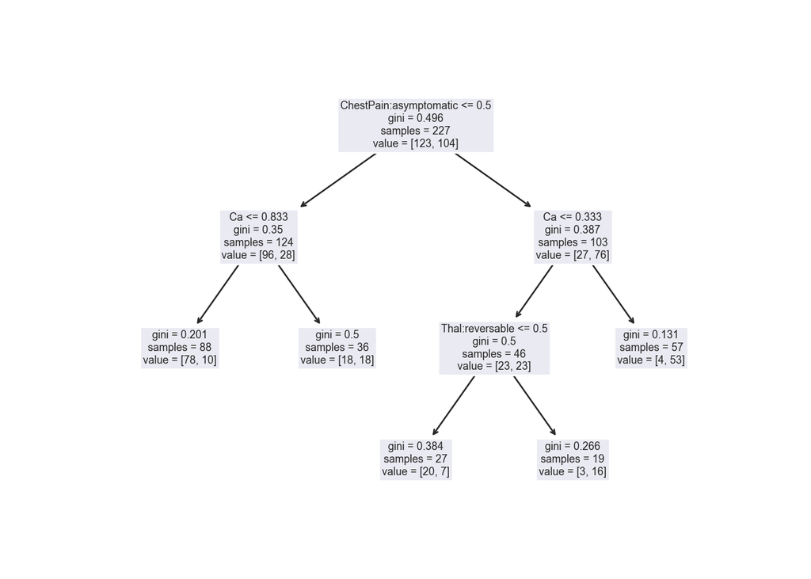

```python
features = np.concatenate([
    features[:-2],
    ['ChestPain:asymptomatic', 'ChestPain:nonanginal', 'ChestPain:nontypical', 'ChestPain:typical'],
    ['Thal:fixed', 'Thal:normal', 'Thal:reversable']
    ])

plt.figure()
plot_tree(
  search.best_estimator_['model'],
  feature_names = features
  );
plt.show()
```

Feature importances:

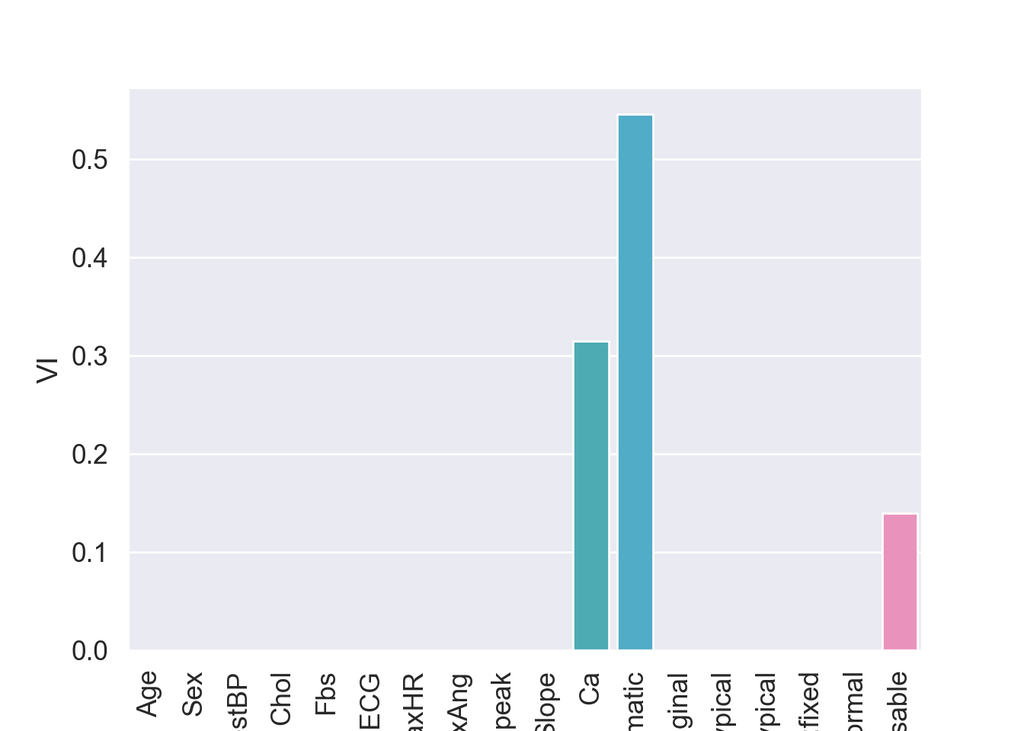

```python
vi_df = pd.DataFrame({
  "feature": features,
  "vi": search.best_estimator_['model'].feature_importances_
  })

plt.figure()
sns.barplot(
  data = vi_df,
  x = "feature",
  y = "vi"
  ).set(
    xlabel = "Feature",
    ylabel = "VI"
);
plt.xticks(rotation = 90);
plt.show()
```

The final AUC on the test set is

```python
roc_auc_score(
  y_test,
  search.best_estimator_.predict_proba(X_test)[:, 1]
  )
```

```
0.8574912891986062
```

The final classification accuracy on the test set is

```python
accuracy_score(
  y_test,
  search.best_estimator_.predict(X_test)
  )
```

```
0.8421052631578947
```

## 10 Visualize the final model

```r
library(rpart.plot)
final_tree <- extract_workflow(final_fit)
final_tree
```

```
══ Workflow [trained] ══════════════════════════════════════════════════════════
Preprocessor: Recipe
Model: decision_tree()

── Preprocessor ────────────────────────────────────────────────────────────────
4 Recipe Steps

• step_naomit()
• step_dummy()
• step_zv()
• step_normalize()

── Model ───────────────────────────────────────────────────────────────────────
n= 148

node), split, n, loss, yval, (yprob)
      * denotes terminal node

 1) root 148 68 No (0.5405405 0.4594595)
   2) Thal_normal>=-0.2062994 89 22 No (0.7528090 0.2471910)
     4) Ca< -0.1631192 64  8 No (0.8750000 0.1250000) *
     5) Ca>=-0.1631192 25 11 Yes (0.4400000 0.5600000)
      10) ChestPain_nonanginal>=0.4419835 7  1 No (0.8571429 0.1428571) *
      11) ChestPain_nonanginal< 0.4419835 18  5 Yes (0.2777778 0.7222222) *
   3) Thal_normal< -0.2062994 59 13 Yes (0.2203390 0.7796610) *
```

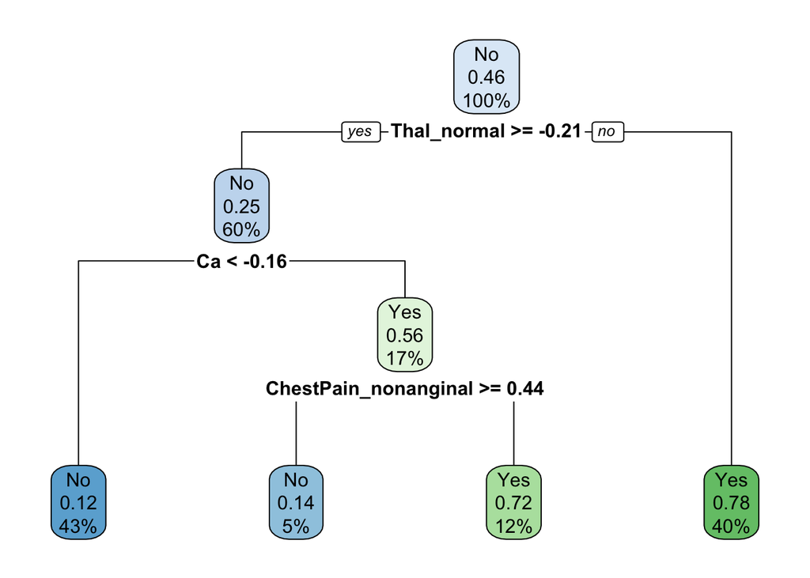

```r
final_tree %>%
  extract_fit_engine() %>%
  rpart.plot(roundint = FALSE)
```

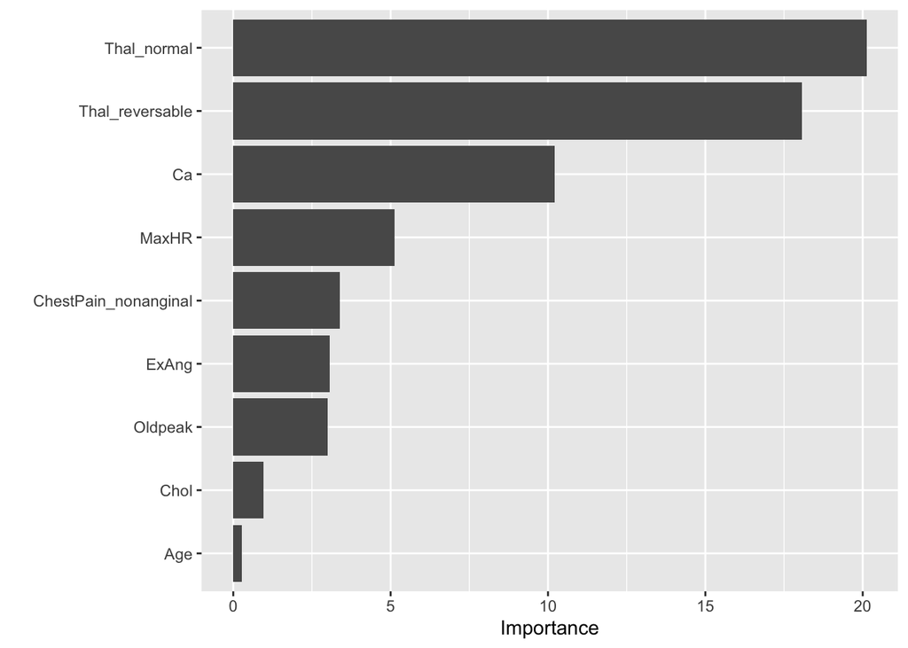

```r
library(vip)

final_tree %>%
  extract_fit_parsnip() %>%
  vip()
```